# Progress Memo 2

Final Project  
Data Science 1 with R (STAT 301-1)

Author

Hailee Kim

Published

November 24, 2024

**Github Repo Link**

[Hailee’s Memo 2 Github Repo (hailee-kim)](https://github.com/hailee-kim/final-project-2-hailee-kim)

## Packages & Datasets

```r
# Loading package
library(tidyverse)

# Loading data
listings <- read_csv("data/listings.csv")
listings_codebook <- read_csv("data/listings_data_dictionary.csv")
```

## Exploratory Data Analysis and Findings

### Bivariate Analysis

Table 1: Summary Statistics for Price within Each City

| city | mean_price | median_price | sd_price | min_price | max_price | n |
| --- | --- | --- | --- | --- | --- | --- |
| Bangkok | 2078.2780 | 1100 | 6379.7880 | 0 | 300177 | 19361 |
| Cape Town | 2405.1204 | 1069 | 6143.1980 | 122 | 180000 | 19086 |
| Hong Kong | 746.1699 | 386 | 1938.2368 | 1 | 83665 | 7087 |
| Istanbul | 532.5574 | 252 | 3318.4206 | 0 | 179532 | 24519 |
| Mexico City | 1149.2530 | 661 | 5372.0149 | 0 | 499000 | 20065 |
| New York | 142.8422 | 99 | 275.7410 | 0 | 10000 | 37012 |
| Paris | 113.0964 | 80 | 214.4337 | 0 | 12000 | 64690 |
| Rio de Janeiro | 742.5893 | 280 | 5368.8688 | 0 | 625216 | 26615 |
| Rome | 105.1076 | 65 | 341.1549 | 0 | 10571 | 27647 |
| Sydney | 222.0134 | 120 | 472.6362 | 5 | 28613 | 33630 |

Table 1 summarizes mean, median, standard deviation, minimum, and maximum prices for Airbnb listings[^1] across ten cities. The mean price varies widely, with cities like Cape Town (2405.12) and Bangkok (2078.28) exhibiting significantly higher averages compared to cities like New York (142.84) and Paris (113.10). However, the large standard deviations in cities such as Cape Town (6143.19) and Bangkok (6379.79) indicate high variability, likely influenced by luxury listings or extreme outliers. Conversely, cities like Paris (214.43) and New York (275.74) display smaller standard deviations, suggesting more consistent pricing across listings. Median prices, which are less sensitive to outliers, highlight that cities like Paris and New York predominantly cater to budget and mid-range accommodations, with median prices at 80 and 99, respectively.

<sup>1</sup> This dataset was sourced from [Maven Analytics](https://www.mavenanalytics.io/data-playground), accessed on November 3rd, 2024.

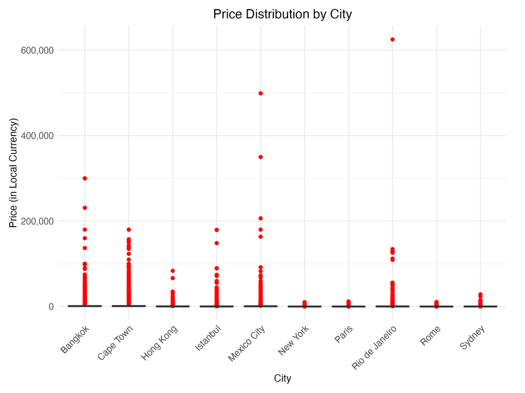

Figure 1: Visualization of price distributions across cities, highlighting disparities, variability, and the impact of outliers on pricing trends

### Multivariate Analysis

Table 2: Correlations Between Price and Selected Variables by City

| city | cor_accommodates | cor_bedrooms | cor_minimum_nights |
| --- | --- | --- | --- |
| Bangkok | 0.1688022 | 0.1645918 | 0.0492920 |
| Cape Town | 0.3949682 | 0.3563259 | 0.0334824 |
| Hong Kong | 0.1672640 | 0.1634916 | -0.0226234 |
| Istanbul | 0.0870714 | 0.0603274 | 0.0024578 |
| Mexico City | 0.1136146 | 0.0738302 | 0.0190444 |
| New York | 0.2765372 | 0.2514875 | 0.0230943 |
| Paris | 0.2745516 | 0.2014397 | 0.0020665 |
| Rio de Janeiro | 0.0907027 | 0.1082308 | 0.0093152 |
| Rome | 0.1350662 | 0.1488791 | -0.0050264 |
| Sydney | 0.3668660 | 0.3931546 | 0.0278050 |

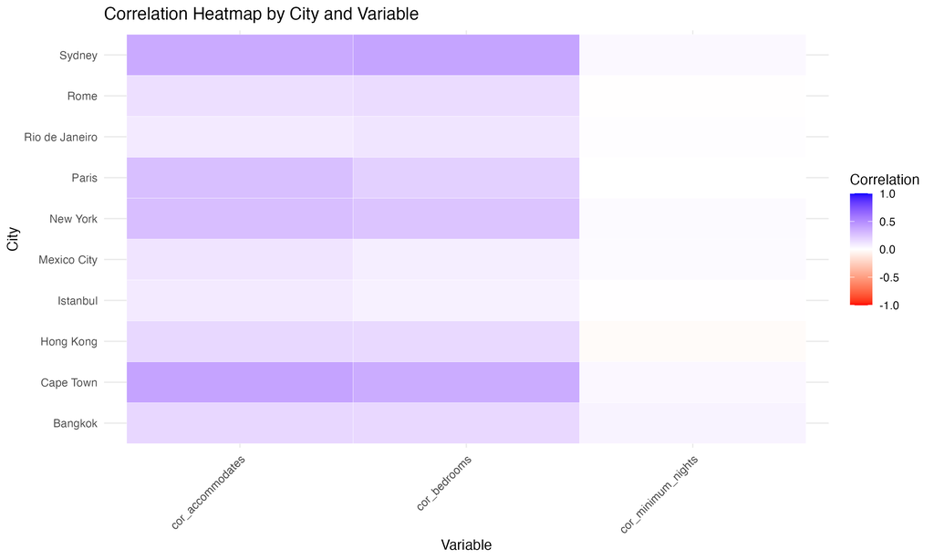

Figure 2: Visual representation of the correlation strength between price and selected variables (accommodates, bedrooms, and minimum nights) across cities

Darker shades in the Figure 2 signify stronger correlations, such as the relationships between accommodates and bedrooms with price in cities like Sydney and Cape Town, where larger properties consistently command higher prices. Conversely, lighter shades denote weaker correlations, particularly for minimum_nights, which appears to have a negligible influence on pricing across all cities.

Overall, Cape Town and Sydney exhibit the strongest overall correlations between price and both accommodates and bedrooms, indicating that property size and capacity are key determinants of pricing in these cities. Accommodates consistently has the highest correlation with price across most cities, followed by bedrooms, reflecting the importance of property size in determining Airbnb prices. Minimum_nights consistently demonstrates weak correlations across all cities, indicating that its impact on pricing is minimal and possibly influenced by local market regulations or norms.

## Research Questions and Curiosity

1. Bivariate analysis
- What is the distribution of Airbnb listing prices in each city, and what patterns can be observed within these distributions?
- Are there outliers or significant differences in price ranges across cities?
2. Multivariate analysis
- How do various features such as the number of guests accommodated, number of bedrooms, and minimum nights correlate with listing prices?
- Which features have the strongest relationship with price, and does this relationship vary by city?

## Progress Summary and Self-Assessment

In this stage of the project, I focused on preparing the dataset for analysis by transforming key variables and addressing challenges related to the data structure. First, I converted multiple columns into factors to enable categorical analysis, including variables such as host_response_time, neighbourhood, district, city, property_type, room_type, and review-related metrics (e.g., review_scores_rating, review_scores_accuracy, and others). This transformation ensures that these variables are appropriately handled in subsequent visualizations and statistical analyses.

Additionally, as part of data tidying, I encountered the limitation that the main dataset (data/listings.csv) was 151.15 MB, exceeding GitHub’s file size limit of 100.00 MB. To address this, I decided to ignore this file in version control and focus on processing and analyzing it locally, ensuring efficient handling of the large dataset while maintaining a clean and manageable repository.

I am confident in my progress and fully expect to complete a thorough analysis by the end of the quarter.

## Future Directions

I experienced a crash in R while attempting to pivot the amenities column, originally stored as a single text field with comma-separated values. My goal was to split these amenities into individual items, clean and standardize their labels, and transform them into separate columns using a pivot operation, where each amenity would be represented as a binary variable (TRUE/FALSE). This approach would enable a more granular analysis of the relationship between amenities and price. To prevent further crashes, I plan to divide the dataset by city, thereby reducing its size and improving runtime efficiency.

For the next stage of the analysis, I plan to focus on the top three cities with the highest number of listings: Paris, New York, and Sydney. Using geospatial data (latitude and longitude), I will create detailed maps for these cities to explore the relationship between location and pricing. This analysis aims to identify which areas within these cities exhibit the highest price tendencies, shedding light on premium neighborhoods that may appeal to travelers seeking luxury accommodations. Additionally, I will investigate the distribution of property_type and room_type across neighborhoods, determining whether certain types of housing (ex. “Entire place” or “Private room”) are concentrated in specific locations. By visualizing these patterns, I aim to uncover spatial trends in housing types and their impact on pricing within these cities.

In addition to geospatial analysis, I plan to incorporate review and amenity data into the current multivariable analysis. Once the amenities list column is properly pivoted, I will explore how customer reviews influence pricing by including review-related variables such as review_scores_rating, review_scores_accuracy, review_scores_cleanliness, review_scores_checkin, review_scores_communication, review_scores_location, and review_scores_value. This step will allow me to determine whether higher review scores correlate with higher prices and to identify which aspects of customer satisfaction (e.g., cleanliness, communication, or location) have the strongest influence on pricing. With the review data already converted to factors, this step is ready for implementation and will add a valuable dimension to the analysis.